# PRACTICAL MACHINE LEARNING COURSE PROJECT

**Author**: Jorge Antunes **Date**: 27/03/2016 This is the final project of the Practical Machine Learning from Johns Hopkins University. The code was tested on OS Win 10 and RStudio Version 0.99.491 In order to fulfill the requirements I’ve followed the available information through the course and the data mining notes from the NOVA IMS.

## Synopsis / Background

Using devices such as Jawbone Up, Nike FuelBand, and Fitbit it is now possible to collect a large amount of data about personal activity relatively inexpensively. These type of devices are part of the quantified self movement - a group of enthusiasts who take measurements about themselves regularly to improve their health, to find patterns in their behavior, or because they are tech geeks. One thing that people regularly do is quantify how much of a particular activity they do, but they rarely quantify how well they do it.

## Introduction

Looking for the Question: **how well they do it**. Five Classes were presented by the datasources A;B;C;D and E. Only Class A is refering to the execution as specified, the remaining classes refer to common mistakes.

Through processing the data it will be possible to understand if the participants are performing well or not the exercises.

## Pratical Part

### Load the Data

The first step is to load the data and the packages

```r
library(AppliedPredictiveModeling)
library(caret)
library(rattle)
```

```r
library(rpart.plot)
library(randomForest)
```

In order to save the data in your local disk, you must use the **setwd()** function

*INPUT DATA:*

```r
download.file(url = "https://d396qusza40orc.cloudfront.net/predmachlearn/pml-training.csv",
              destfile = "pml-training.csv")
download.file(url = "https://d396qusza40orc.cloudfront.net/predmachlearn/pml-testing.csv",
              destfile = "pml-testing.csv")
# Import the data treating empty values as NA.
training <- read.csv("pml-training.csv", na.strings=c("NA",""), header=TRUE)
testing <- read.csv("pml-testing.csv", na.strings=c("NA",""), header=TRUE)
```

### Perform the first Pre-Process task

#### I want to remove all the columns that have more than 95% NAs

```r
toEliminate <- vector("list",length(training))
for(i in 1:length(training)) {
        if( sum( is.na(training[,i])) / nrow(training) >= 0.95) {
                toEliminate[i] <- names(training)[i]
                        }
                }

varsToKeep <- !(names(training) %in% toEliminate)
newTraining <- training[,varsToKeep]
```

I also want to remove the variables that don’t add any value, once covariance equals to zero

```r
nzv <- nearZeroVar(newTraining, saveMetrics=TRUE)
newTraining <- newTraining[,nzv$nzv == FALSE,]
```

The remaining variables the first 6 also doesn’t provide any value to the Prediction model

```r
newTraining <- newTraining[,-c(1:6)]
```

I’ll divide the training dataset in two, one to be processed with Decision Trees and the other with Random Forests

```r
set.seed(1)
toDivide <- createDataPartition(y=newTraining$classe, p=0.5, list=FALSE)
#The dataset to be used in the Decision Trees
dtTraining <- newTraining[toDivide,]
#The dataset to be used in the Random Forests
rfTraining <- newTraining[-toDivide,]
#Now let's divide both training sets into training and testing
set.seed(1)
dt_inTrain <- createDataPartition(y=dtTraining$classe, p=0.6, list=FALSE)
dtTraining1 <- dtTraining[dt_inTrain,]
dtTesting1 <- dtTraining[-dt_inTrain,]
set.seed(1)
rf_inTrain <- createDataPartition(y=rfTraining$classe, p=0.6, list=FALSE)
rfTraining1 <- rfTraining[rf_inTrain,]
rfTesting1 <- rfTraining[-rf_inTrain,]
```

Finally we arrive to the Algorithms phase

## ML algortithms

### Decision Tree

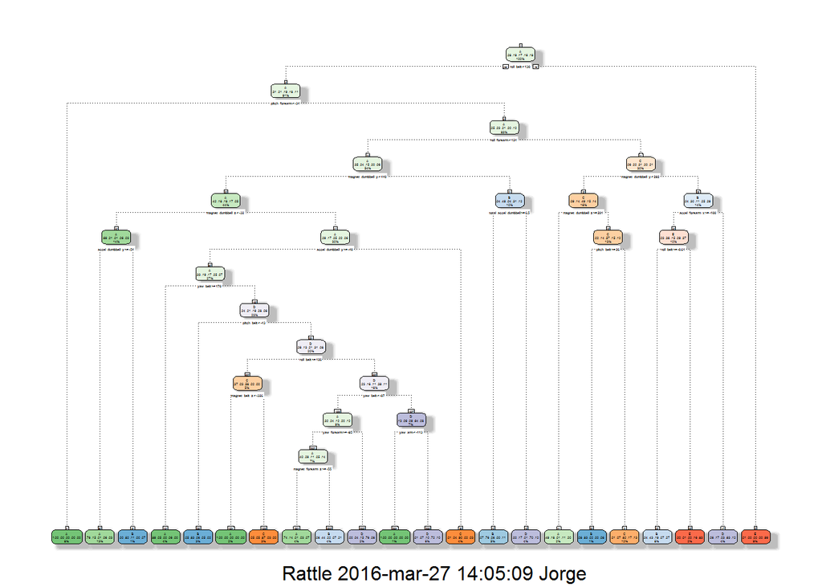

```r
set.seed(1)
modFitA1 <- rpart(classe ~ .,
                  data=dtTraining1,
                  method="class")
#The resulting Decision Tree
fancyRpartPlot(modFitA1)
```

```r
predictionsA1 <- predict(modFitA1, dtTesting1, type = "class")
```

The final Accuracy is 0.7221514

```r
confusionMatrix(predictionsA1, dtTesting1$classe)
```

```
## Confusion Matrix and Statistics
##
##           Reference
## Prediction    A    B    C    D    E
##          A 1029  140    9   58   50
##          B   51  504  128   40  148
##          C   20   51  500  103   84
##          D   15   64   47  432   71
##          E    1    0    0   10  368
##
## Overall Statistics
##
##                Accuracy : 0.7222
##                  95% CI : (0.7078, 0.7361)
##     No Information Rate : 0.2845
##     P-Value [Acc > NIR] : < 2.2e-16
##
##                   Kappa : 0.6465
##  Mcnemar's Test P-Value : < 2.2e-16
##
## Statistics by Class:
##
##                      Class: A Class: B Class: C Class: D Class: E
## Sensitivity            0.9220   0.6640   0.7310   0.6719  0.51040
## Specificity            0.9084   0.8840   0.9203   0.9399  0.99656
## Pos Pred Value         0.8002   0.5786   0.6596   0.6868  0.97098
## Neg Pred Value         0.9670   0.9164   0.9419   0.9359  0.90040
## Prevalence             0.2845   0.1935   0.1744   0.1639  0.18379
## Detection Rate         0.2623   0.1285   0.1275   0.1101  0.09381
## Detection Prevalence   0.3278   0.2220   0.1932   0.1603  0.09661
## Balanced Accuracy      0.9152   0.7740   0.8257   0.8059  0.75348
```

### Generalized Boosted Regression

```r
set.seed(1)
modFitGBR <- train(rfTraining1$classe ~ .,
                method="gbm",
                preProcess=c("center", "scale"),
                trControl=trainControl(method = "repeatedcv",
                                       number = 10),
                data=rfTraining1)
print(modFitGBR)
```

```
## Stochastic Gradient Boosting
##
## 5887 samples
##   52 predictor
##    5 classes: 'A', 'B', 'C', 'D', 'E'
##
## Pre-processing: centered (52), scaled (52)
## Resampling: Cross-Validated (10 fold, repeated 1 times)
## Summary of sample sizes: 5300, 5300, 5298, 5297, 5298, 5299, ...
## Resampling results across tuning parameters:
##
##   interaction.depth  n.trees  Accuracy   Kappa      Accuracy SD
##   1                   50      0.7455504  0.6771570  0.015400800
##   1                  100      0.8143447  0.7649387  0.018677930
##   1                  150      0.8469613  0.8063676  0.016627469
##   2                   50      0.8471253  0.8062482  0.014669311
##   2                  100      0.9035231  0.8778728  0.010522094
##   2                  150      0.9267824  0.9073156  0.011294242
##   3                   50      0.8919654  0.8632185  0.013382712
##   3                  100      0.9351091  0.9178778  0.011646038
##   3                  150      0.9512535  0.9383194  0.008669031
##   Kappa SD
##   0.01953957
##   0.02371547
##   0.02107311
##   0.01864495
##   0.01328769
##   0.01425728
##   0.01692829
##   0.01471492
##   0.01096057
##
## Tuning parameter 'shrinkage' was held constant at a value of 0.1
##
## Tuning parameter 'n.minobsinnode' was held constant at a value of 10
## Accuracy was used to select the optimal model using  the largest value.
## The final values used for the model were n.trees = 150,
##  interaction.depth = 3, shrinkage = 0.1 and n.minobsinnode = 10.
```

```r
predictions <- predict(modFitGBR, newdata=rfTesting1)
print(confusionMatrix(predictions, rfTesting1$classe))
```

```
## Confusion Matrix and Statistics
##
##           Reference
## Prediction    A    B    C    D    E
##          A 1097   28    0    2    3
##          B   11  705   16    1    8
##          C    5   21  662   32    9
##          D    3    2    5  597    7
##          E    0    3    1   11  694
##
## Overall Statistics
##
##                Accuracy : 0.9572
##                  95% CI : (0.9504, 0.9633)
##     No Information Rate : 0.2845
##     P-Value [Acc > NIR] : < 2.2e-16
##
##                   Kappa : 0.9458
##  Mcnemar's Test P-Value : 1.506e-06
##
## Statistics by Class:
##
##                      Class: A Class: B Class: C Class: D Class: E
## Sensitivity            0.9830   0.9289   0.9678   0.9285   0.9626
## Specificity            0.9882   0.9886   0.9793   0.9948   0.9953
## Pos Pred Value         0.9708   0.9514   0.9081   0.9723   0.9788
## Neg Pred Value         0.9932   0.9830   0.9931   0.9861   0.9916
## Prevalence             0.2845   0.1935   0.1744   0.1639   0.1838
## Detection Rate         0.2796   0.1797   0.1687   0.1522   0.1769
## Detection Prevalence   0.2880   0.1889   0.1858   0.1565   0.1807
## Balanced Accuracy      0.9856   0.9587   0.9736   0.9616   0.9789
```

### Random Forests

```r
set.seed(1)
modFit <- train(rfTraining1$classe ~ .,
                method="rf",
                preProcess=c("center", "scale"),
                trControl=trainControl(method = "cv",
                                       number = 10),
                data=rfTraining1)
print(modFit)
```

```
## Random Forest
##
## 5887 samples
##   52 predictor
##    5 classes: 'A', 'B', 'C', 'D', 'E'
##
## Pre-processing: centered (52), scaled (52)
## Resampling: Cross-Validated (10 fold)
## Summary of sample sizes: 5300, 5300, 5298, 5297, 5298, 5299, ...
## Resampling results across tuning parameters:
##
##   mtry  Accuracy   Kappa      Accuracy SD  Kappa SD
##    2    0.9797867  0.9744216  0.006420286  0.008128601
##   27    0.9801256  0.9748537  0.004808018  0.006087129
##   52    0.9678804  0.9593588  0.009408671  0.011912224
##
## Accuracy was used to select the optimal model using  the largest value.
## The final value used for the model was mtry = 27.
```

Let’s look at the predictions with the *Random Forests*

```r
predictions <- predict(modFit, newdata=rfTesting1)
print(confusionMatrix(predictions, rfTesting1$classe))
```

```
## Confusion Matrix and Statistics
##
##           Reference
## Prediction    A    B    C    D    E
##          A 1113    7    0    0    0
##          B    1  740    6    0    0
##          C    1   12  674   17    1
##          D    0    0    4  623    2
##          E    1    0    0    3  718
##
## Overall Statistics
##
##                Accuracy : 0.986
##                  95% CI : (0.9818, 0.9894)
##     No Information Rate : 0.2845
##     P-Value [Acc > NIR] : < 2.2e-16
##
##                   Kappa : 0.9823
##  Mcnemar's Test P-Value : NA
##
## Statistics by Class:
##
##                      Class: A Class: B Class: C Class: D Class: E
## Sensitivity            0.9973   0.9750   0.9854   0.9689   0.9958
## Specificity            0.9975   0.9978   0.9904   0.9982   0.9988
## Pos Pred Value         0.9938   0.9906   0.9560   0.9905   0.9945
## Neg Pred Value         0.9989   0.9940   0.9969   0.9939   0.9991
## Prevalence             0.2845   0.1935   0.1744   0.1639   0.1838
## Detection Rate         0.2837   0.1886   0.1718   0.1588   0.1830
## Detection Prevalence   0.2855   0.1904   0.1797   0.1603   0.1840
## Balanced Accuracy      0.9974   0.9864   0.9879   0.9835   0.9973
```

The Accuracy is 0.9859801

### Apply to the Testing SET

The testing datasource is the one without any help, the class variable is missing so we must trust on our best model. The accuracy obtained with the Random forests is so good with a out of sample error really small 0.0140199

Let’s take a look at our predictions

```r
colu <- names(newTraining)
colu <- colu[-53]
newTesting <- testing[,colu]
final <- predict(modFit, newdata=newTesting)
```

The final prediction is

```r
print(final)
```

```
##  [1] B A B A A E D B A A B C B A E E A B B B
## Levels: A B C D E
```